# Time Series Analysis of daily CO₂ emissions data

Ella Ashburn

2026-02-18

# Abstract

This project analyzes daily CO₂ emissions from the U.S. power sector using data from the Carbon Monitor dataset covering January 1, 2019 to December 5, 2023. The goal of the project was to examine the temporal structure of the series and compare the forecasting performance of two time series methods: a SARIMA model and a Gaussian state space model. After cleaning the data and constructing a univariate daily time series, the series was analyzed using plots of the original and differenced data, ACF and PACF plots, model estimation, diagnostic checks, and out-of-sample forecasting. The results showed that the data contain clear time dependence and repeating short-term patterns. Overall, the SARIMA model performed better than the Gaussian state space model because it was better able to capture the main temporal structure of the series and produced more reasonable forecasts for the test period. This project shows that daily CO₂ emissions data can be effectively studied using time series methods and that model choice plays an important role in forecast performance.

# 1. Introduction

Carbon dioxide emissions from fossil fuel use and cement production are a major driver of climate change, so timely emissions data are important for both environmental research and policy. One challenge in climate-related data analysis is that official emissions inventories are often released with substantial delays. Carbon Monitor was developed to address this problem by providing near-real-time daily estimates of CO₂ emissions at national levels. The dataset captures daily, weekly, and seasonal variation and has also been used to document major shifts in emissions during the COVID-19 period.

I chose this topic because I am double majoring in Data Science and Environmental Studies, and I am especially interested in applying statistical methods to environmental data sets. CO₂ emissions are an important variable to study because they are directly related to climate change, public health, and environmental justice. In addition, this data set is interesting because it provides emissions by both country and sector, allowing patterns in human activity and energy use to be observed.

For this project, I focused on daily CO₂ emissions from the U.S. power sector and analyzed the data as a univariate time series. The main goal of the project was to examine patterns in the series and compare the forecasting performance of two methods, a SARIMA model and a Gaussian state space model. More specifically, this project investigates whether these models can capture the temporal structure in daily CO₂ emissions and provide reasonable short-term forecasts. Overall, the analysis showed that the series contains clear time dependence and can be modeled using standard time series methods, although the data also reflect real-world disruptions and variation over time.

## 2. Data

The data set used in this project contains daily CO₂ emissions data from January 1, 2019 to December 5, 2023. The data frequency is daily, and the emissions are reported in metric tons of CO₂. The full data set contains 135,408 observations and 6 variables. These variables include country, date, sector, emissions value, time stamp, and the formatted date variable created during data cleaning. This data set was obtained from Kaggle ( https://www.kaggle.com/datasets/saloni1712/co2-emissions/data), but the original source of the data is Carbon Monitor. Carbon Monitor provides near real time daily CO₂ emissions estimates at the national level. The data set includes emissions from different countries and sectors, which makes it useful for studying how emissions vary over time and across different parts of the economy. The data were collected using information from UNFCCC national greenhouse gas inventories as baseline emissions. Emission changes were then estimated using activity data and approximations, including average emission variations observed in countries with available data. I chose this data set because I am interested in working with environmentally related data sets like this one also chose it because CO₂ emissions are directly connected to climate change, public health, and environmental justice. Since the data set includes both country and sector level information, it allows patterns in emissions to be studied at a much higher temporal resolution than annual emissions data sets.

## 3. Methodology

This project focuses on one univariate daily time series taken from the larger Carbon Monitor CO₂ emissions data set. Since the original data set contains multiple countries and sectors, the data first had to be cleaned and filtered so that one time series could be modeled. For this project, the selected series was daily CO₂ emissions from the U.S. power sector from January 1, 2019 to December 5, 2023. The date column was converted into a proper date format, rows with missing values were removed, and the data were arranged in chronological order.

Because the data are daily, the time series was created using a frequency of 7 to allow for possible weekly seasonality. The data were then split into a training set and a test set, where 80% of the observations were used to fit the models and the remaining 20% were used to evaluate forecast accuracy. Two models were applied in this project: a SARIMA model and a Gaussian state space model.

The first method used was a SARIMA model. This model is beneficial because it can account for autocorrelation, differencing, and possible seasonal structure in the data. The original time series was first plotted and the ACF and PACF were examined to better understand the dependence in the series. Since stationarity is important for ARIMA-type models, the series was also checked to determine whether differencing was needed. Differencing was then used ($\Delta y_t = y_t - y_t - 1$) to stabilize the series. After this, auto.arima() was used to select the final SARIMA model. As a second method, a Gaussian state space model was fitted to the same daily CO₂ emissions series. State space models are useful because they describe the observed series using underlying hidden states, such as a changing level or trend over time. In this project, the model was fitted using a structural time series approach and estimation was carried out using the Kalman filter. Like the SARIMA model, the state space model was fit using the training data only. Forecasts were then generated for the test period and compared with the observed values.

## 4. Results

#### SARIMA Results

*Original Series Plot*

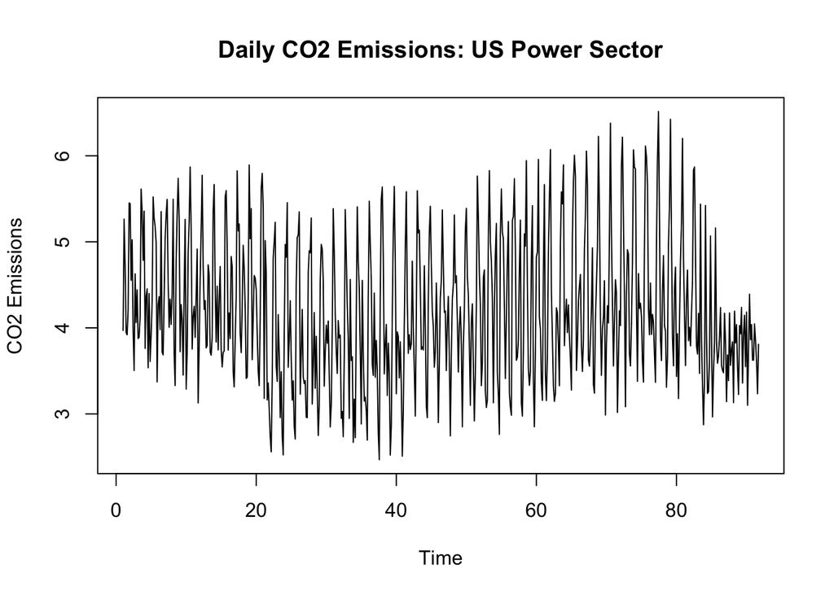

This figure shows the original daily CO₂ emissions series for the U.S. power sector. The series shows clear time dependence and does not behave like random noise. The figure show a repeating pattern over time emissions mostly bouncing between 2.5 and 6.5. This series frequency decreasing over time. This implies that the original series is not stationary.

*ACF/PACF of original Series*

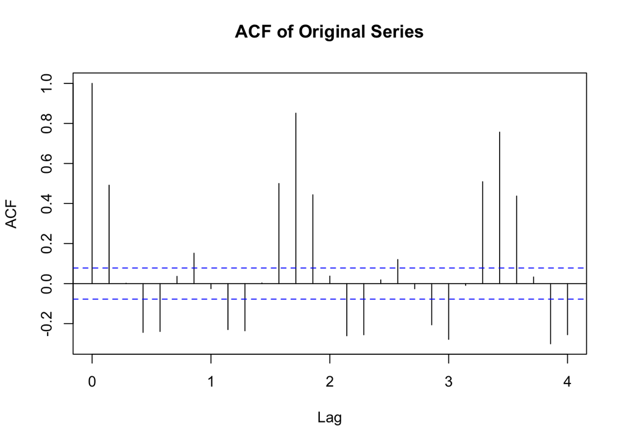

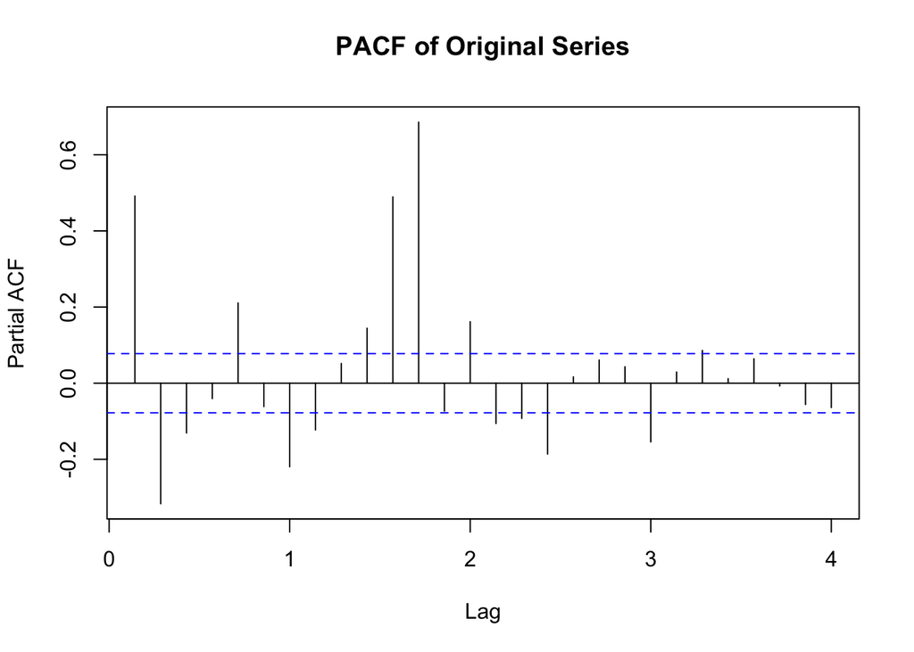

*Transformed Series Plot*

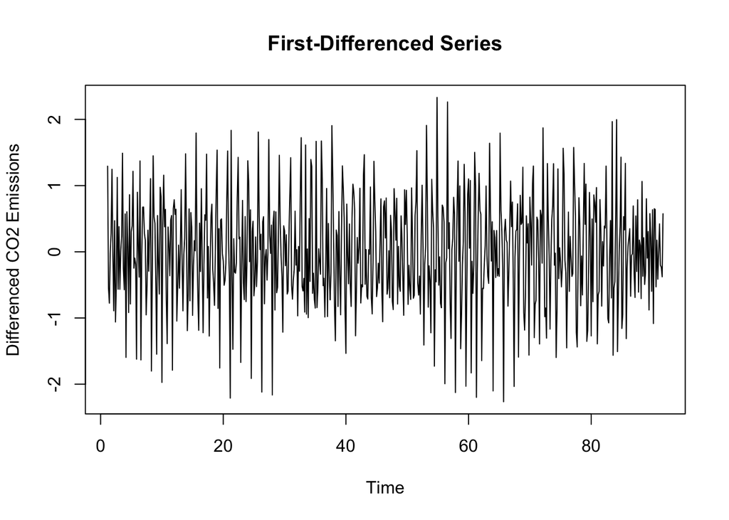

In the figure it can be sent that the differenced series is centered much more closely around zero then the original time series. This means that the differencing helped stabilize the mean of the series and made better for modeling.

*Plot ACF/PACF of differenced time series*

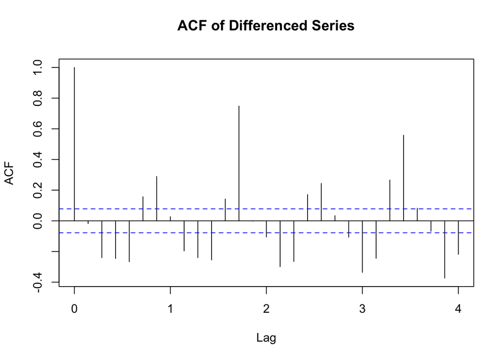

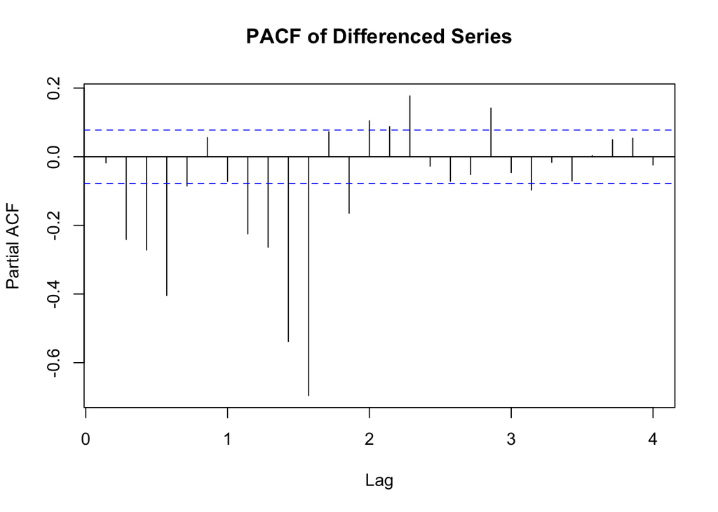

The ACF and PACF of the differenced series were used to examine the remaining dependence after transformation. Although differencing reduced the nonstationarity in the series, several significant spikes remained in both the ACF and PACF. This indicates that autoregressive and moving average terms were still needed in the final model.

*Estimation Results*

```
## Series: train_ts
## ARIMA(2,1,3)
##
## Coefficients:
##          ar1      ar2      ma1     ma2     ma3
##       0.9677  -0.9478  -1.6709  1.5966  -0.890
## s.e.  0.0185   0.0173   0.0297  0.0313   0.019
##
## sigma^2 = 0.3789:  log likelihood = -473.84
## AIC=959.69   AICc=959.86   BIC=985.06
##
## Training set error measures:
##                        ME      RMSE       MAE       MPE     MAPE      MASE
## Training set -0.002187548 0.6119404 0.5016669 -2.245255 12.53125 0.5006304
##                   ACF1
## Training set 0.1616985
```

*Diagnostics*

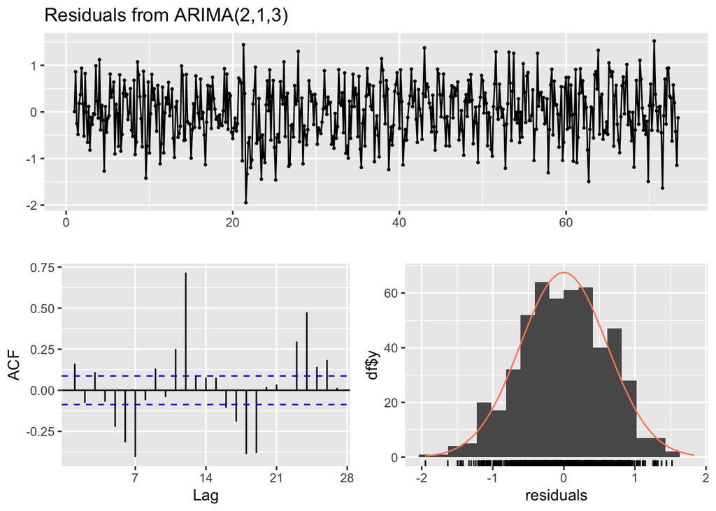

```
##
##  Ljung-Box test
##
## data:  Residuals from ARIMA(2,1,3)
## Q* = 508.76, df = 9, p-value < 2.2e-16
##
## Model df: 5.   Total lags used: 14
```

The residual diagnostics show that the residuals are generally centered around zero and the histogram appears roughly bell-shaped. However, the residual ACF still contains several significant spikes, which suggests that some autocorrelation remains in the residuals. This means that the ARIMA(2,1,3) model captures much of the structure in the series, but it may not fully account for all of the repeating dependence in the data.

*Forecast plot + Accuracy*

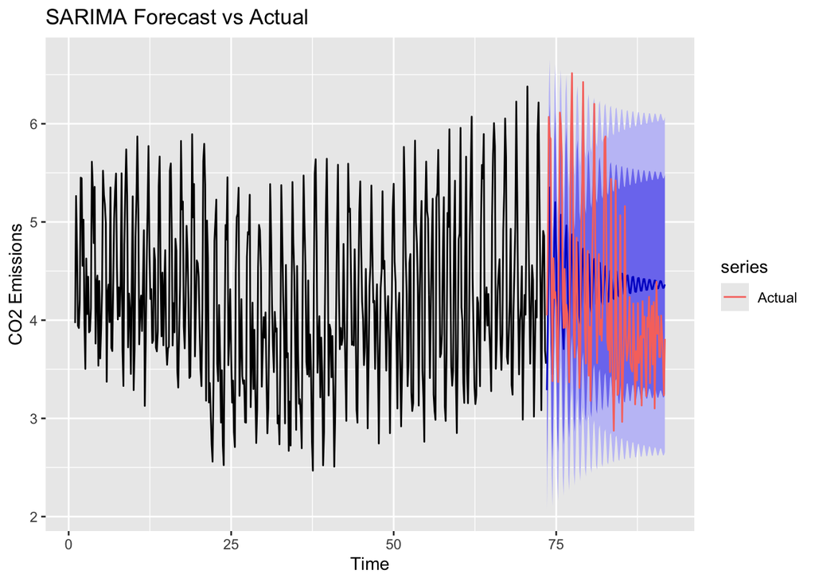

```
##                        ME      RMSE       MAE       MPE     MAPE      MASE
## Training set -0.002187548 0.6119404 0.5016669 -2.245255 12.53125 0.5006304
## Test set     -0.179945563 0.7417771 0.6375647 -7.256616 15.71332 0.6362475
##                   ACF1 Theil's U
## Training set 0.1616985        NA
## Test set     0.5351669 0.9421377
```

### Results of Gaussian State Space Model (Local Linear Trend State Space Model)

*Fit the state space model*

```
##
## Call:
## StructTS(x = train_ts, type = "trend")
##
## Variances:
##   level    slope  epsilon
## 0.69240  0.00000  0.01402
```

The variance estimates showed that the model mainly captured changes in the level of the series, while the slope variance was estimated to be zero. This means the model did not identify much evidence of a changing trend over time.

*Forecast*

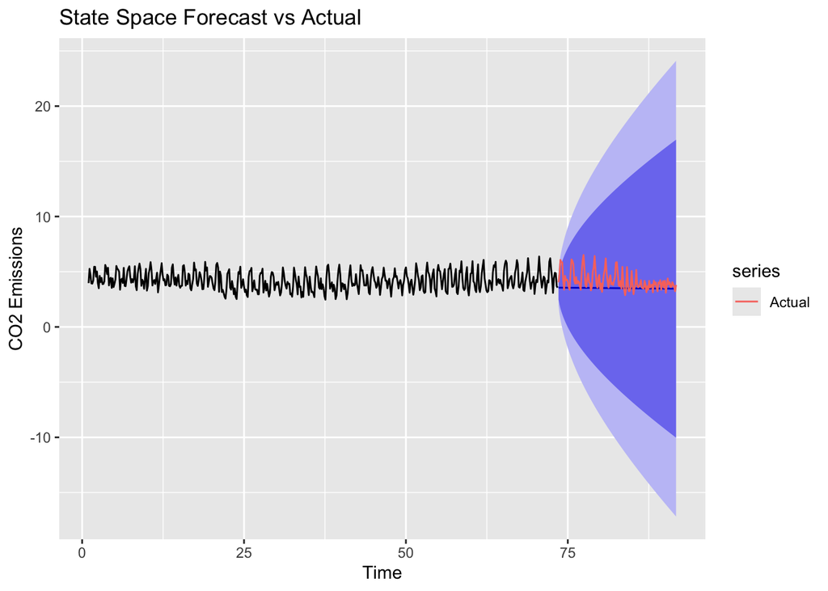

```
##                        ME      RMSE       MAE       MPE     MAPE      MASE
## Training set -0.004939754 0.8486188 0.6814990 -2.271815 16.74334 0.6800910
## Test set      0.666229396 1.0392499 0.7434846 13.182987 15.62774 0.7419485
##                    ACF1 Theil's U
## Training set 0.00423831        NA
## Test set     0.51516025  1.182522
```

From the forecast plot, the state space model did not do as good of a job as the SARIMA model. It did not capture the strong repeating pattern in the test data, and the forecast intervals became very wide as the forecast moved forward. This suggests that the model was too simple for this data set and that it was not able to capture the main temporal structure of the daily CO₂ emissions series.

*Diagnostics*

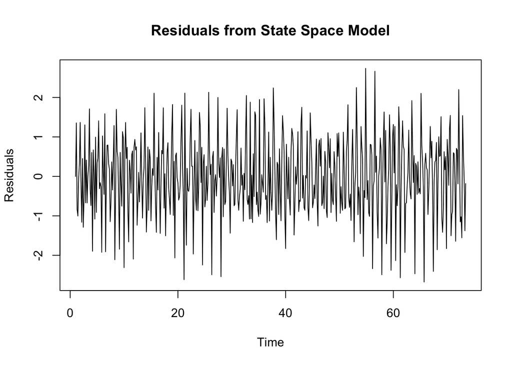

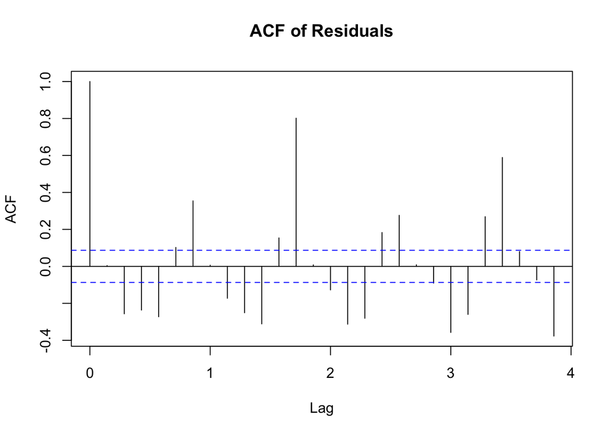

This residual diagnostic also suggest that the model fit was limited. Overall, the Gaussian state space model provided a weaker fit than the SARIMA model and appeared less suitable for forecasting this series.

*Compare accuracy of two models*

```
##                        ME      RMSE       MAE       MPE     MAPE      MASE
## Training set -0.004939754 0.8486188 0.6814990 -2.271815 16.74334 0.6800910
## Test set      0.666229396 1.0392499 0.7434846 13.182987 15.62774 0.7419485
##                    ACF1 Theil's U
## Training set 0.00423831        NA
## Test set     0.51516025  1.182522
```

```
##                        ME      RMSE       MAE       MPE     MAPE      MASE
## Training set -0.002187548 0.6119404 0.5016669 -2.245255 12.53125 0.5006304
## Test set     -0.179945563 0.7417771 0.6375647 -7.256616 15.71332 0.6362475
##                   ACF1 Theil's U
## Training set 0.1616985        NA
## Test set     0.5351669 0.9421377
```

Overall, the SARIMA model performed better than the Gaussian state space model because it was better able to capture the repeating temporal structure in the daily CO₂ emissions series, while the state space model produced wider uncertainty bands and less accurate forecasts.

## Conclusion

This project examined daily CO₂ emissions from the U.S. power sector using the Carbon Monitor dataset from January 1, 2019 to December 5, 2023. The goal of the project was to analyze the temporal structure of the series and compare the forecasting performance of a SARIMA model and a Gaussian state space model. Overall, the data showed clear time dependence and repeating short-term patterns, confirming that time series methods were appropriate for this data set. The most important finding of this project was that the SARIMA model performed better than the Gaussian state space model for forecasting this series. After first differencing, the SARIMA model was able to capture the main temporal structure of the data and produced more reasonable forecasts for the test period. In contrast, the Gaussian state space model was too simple to capture the strong repeating behavior in the series and produced much wider forecast uncertainty. Overall, this project showed that daily CO₂ emissions data contain meaningful statistical structure that can be modeled and forecasted, but the choice of model matters. For this particular dataset, the SARIMA approach was more effective because it was better able to represent the short-term dependence and repeated variation present in the daily U.S. power-sector CO₂ emissions series.

## Refrences

Saloni Jhalani. “CO2 Emissions by Sectors.” Kaggle.com, 2024, www.kaggle.com/datasets/saloni1712/co2-emissions/data. Accessed 13 Mar. 2026.

GeeksforGeeks. “SARIMA (Seasonal Autoregressive Integrated Moving Average).” GeeksforGeeks, 17 Nov. 2023, www.geeksforgeeks.org/machine-learning/sarima-seasonal-autoregressive-integrated-moving-average/.

Unfccc.int, 2022, unfccc.int/topics/mitigation/resources/registry-and-data/ghg-data-from-unfccc.

## Appendix

### R code

*Load in necessary packages*

```r
library(dplyr)
library(lubridate)
library(forecast)
library(ggplot2)
```

*Data Cleaning*

```r
# Load in Data
df <- read.csv("/Users/beepbop/Desktop/PSTAT 174/dataset.csv",  stringsAsFactors = FALSE)

# Convert Data Column
df$date2 <- as.Date(df$date, format = "%m/%d/%Y")

# Remove rows with missing key values
df_clean <- df %>%
  filter(!is.na(date2),
         !is.na(country),
         !is.na(sector),
         !is.na(value))
```

*Original Series Plot*

```r
# Plot original series
plot(us_ts, main = "Daily CO2 Emissions: US Power Sector",
     ylab = "CO2 Emissions", xlab = "Time")
```

*ACF/PACF of original Series*

```r
# ACF and PACF of original series
acf(us_ts, main = "ACF of Original Series")
pacf(us_ts, main = "PACF of Original Series")
```

*Time Series Creation*

```r
# Filter one uni variate daily time series
us_data <- df_clean %>%
  filter(country == "US", sector == "Power") %>%
  arrange(date2)

# Check for missing dates
all_dates <- seq(min(us_data$date2), max(us_data$date2), by = "day")
missing_dates <- setdiff(all_dates, us_data$date2)
length(missing_dates)

# Create daily time series
# Use frequency = 7 to capture weekly seasonality
us_ts <- ts(us_data$value, frequency = 7)
```

*Transforming Data*

```r
# Check stationary and apply differencing if needed
ndiffs(us_ts)
nsdiffs(us_ts)

# Transformed Data (first-differrenced series)
diff_ts <- diff(us_ts, differences = 1)
```

*Transformed Series Plot*

```r
# Plot Transformed series
plot(diff_ts,
     main = "First-Differenced Series",
     ylab = "Differenced CO2 Emissions",
     xlab = "Time")
```

*Plot ACF/PACF of differenced time series*

```r
acf(diff_ts, main = "ACF of Differenced Series")
pacf(diff_ts, main = "PACF of Differenced Series")
```

*SARIMA Fitting Code/ Model Selection*

```r
# Train/test split
n <- length(us_ts)
train_size <- floor(0.8 * n)

n <- length(us_ts)
train_size <- floor(0.8 * n)

train_ts <- window(us_ts, end = time(us_ts)[train_size])
test_ts  <- window(us_ts, start = time(us_ts)[train_size + 1])

# Fit SARIMA model
fit_sarima <- auto.arima(train_ts, seasonal = TRUE, stepwise = FALSE, approximation = FALSE)
```

*Estimation Results*

```r
summary(fit_sarima)
```

*Diagnostics*

```r
# Diagnostic checks
checkresiduals(fit_sarima)
```

*Forecast plot + Accuracy*

```r
# Forecast over test period
fc_sarima <- forecast(fit_sarima, h = length(test_ts))

# Plot forecast vs actual
autoplot(fc_sarima) +
  autolayer(test_ts, series = "Actual") +
  ggtitle("SARIMA Forecast vs Actual") +
  xlab("Time") + ylab("CO2 Emissions")

# Accuracy metrics
accuracy(fc_sarima, test_ts)
```

*Fit the state space model*

```r
fit_ss <- StructTS(train_ts, type = "trend")
fit_ss
```

*Forecast*

```r
fc_ss <- forecast(fit_ss, h = length(test_ts))

autoplot(fc_ss) +
  autolayer(as.ts(test_ts), series = "Actual") +
  ggtitle("State Space Forecast vs Actual") +
  xlab("Time") + ylab("CO2 Emissions")

accuracy(fc_ss, test_ts)
```

*State Space Model Residuals*

```r
res_ss <- residuals(fit_ss)

par(mfrow = c(2,1), mar = c(4,4,2,1))
```

*Diagnostics*

```r
plot(res_ss, main = "Residuals from State Space Model", ylab = "Residuals")
acf(res_ss, main = "ACF of Residuals")
par(mfrow = c(1,1))
```

*Compare accuracy of two models*

```r
accuracy(fc_ss, test_ts)
accuracy(fc_sarima, test_ts)
```